# Web Scraping

Biostat 203B

Author

Dr. Hua Zhou @ UCLA

Published

February 13, 2025

Load tidyverse and other packages for this lecture.

```r
library("tidyverse")
library("rvest")
library("quantmod")
```

## 1 Web scraping

There is a wealth of data on internet. How to scrape them and analyze them?

## 2 rvest

rvest is an R package written by Hadley Wickham which makes web scraping easy.

## 3 Example: Scraping from webpage

- We follow instructions in a [Blog by SAURAV KAUSHIK](https://www.analyticsvidhya.com/blog/2017/03/beginners-guide-on-web-scraping-in-r-using-rvest-with-hands-on-knowledge/) to find the most popular feature films of 2023.
- Install the SelectorGadget by dragging the link to your bookmark.
- The 25 most popular feature films released in 2023 can be accessed at page https://www.imdb.com/search/title/?title_type=feature&release_date=2023-01-01,2023-12-31&count=25.

```r
# Specifying the url for desired website to be scraped
url <- "https://www.imdb.com/search/title/?title_type=feature&release_date=2023-01-01,2023-12-31&count=25"
# Reading the HTML code from the website
(webpage <- read_html(url))
```

```
{html_document}
<html lang="en-US" xmlns:og="http://opengraphprotocol.org/schema/" xmlns:fb="http://www.facebook.com/2008/fbml">
[1] <head>\n<meta http-equiv="Content-Type" content="text/html; charset=UTF-8 ...
[2] <body>\n<div>    <img height="1" width="1" style="display:none;visibility ...
```

[figure not shown]

### 3.1 Rank and title

- Use SelectorGadget to find the CSS selector `.ipc-title-link-wrapper .ipc-title__text`.

```r
# Using CSS selectors to scrap the title section
ranktitle_data <- webpage |>
  html_elements('.ipc-title-link-wrapper .ipc-title__text') |>
  html_text() |>
  print()
```

```
 [1] "1. Oppenheimer"
 [2] "2. Poor Things"
 [3] "3. Sing Sing"
 [4] "4. The Bikeriders"
 [5] "5. Infinity Pool"
 [6] "6. Lee"
 [7] "7. Anyone But You"
 [8] "8. Mission: Impossible - Dead Reckoning Part One"
 [9] "9. Leave the World Behind"
[10] "10. Barbie"
[11] "11. Hit Man"
[12] "12. Strange Darling"
[13] "13. Woman of the Hour"
[14] "14. The Super Mario Bros. Movie"
[15] "15. Scream VI"
[16] "16. Killers of the Flower Moon"
[17] "17. Perfect Days"
[18] "18. The Creator"
[19] "19. Guardians of the Galaxy Vol. 3"
[20] "20. The Zone of Interest"
[21] "21. Spider-Man: Across the Spider-Verse"
[22] "22. Saltburn"
[23] "23. John Wick: Chapter 4"
[24] "24. Culpa Mía"
[25] "25. Indiana Jones and the Dial of Destiny"
```

```r
# rank
rank_data <- str_extract(ranktitle_data, "^[0-9]+") |>
  as.integer() |>
  print()
```

```
 [1]  1  2  3  4  5  6  7  8  9 10 11 12 13 14 15 16 17 18 19 20 21 22 23 24 25
```

```r
# title
title_data <- str_remove(ranktitle_data, "^[0-9]+. ") |>
  print()
```

```
 [1] "Oppenheimer"
 [2] "Poor Things"
 [3] "Sing Sing"
 [4] "The Bikeriders"
 [5] "Infinity Pool"
 [6] "Lee"
 [7] "Anyone But You"
 [8] "Mission: Impossible - Dead Reckoning Part One"
 [9] "Leave the World Behind"
[10] "Barbie"
[11] "Hit Man"
[12] "Strange Darling"
[13] "Woman of the Hour"
[14] "The Super Mario Bros. Movie"
[15] "Scream VI"
[16] "Killers of the Flower Moon"
[17] "Perfect Days"
[18] "The Creator"
[19] "Guardians of the Galaxy Vol. 3"
[20] "The Zone of Interest"
[21] "Spider-Man: Across the Spider-Verse"
[22] "Saltburn"
[23] "John Wick: Chapter 4"
[24] "Culpa Mía"
[25] "Indiana Jones and the Dial of Destiny"
```

### 3.2 Description

```r
description_data <- webpage |>
  html_elements('.ipc-html-content-inner-div') |>
  html_text() |>
  print()
```

```
 [1] "A dramatization of the life story of J. Robert Oppenheimer, the physicist who had a large hand in the development of the atomic bombs that brought an end to World War II."
 [2] "An account of the fantastical evolution of Bella Baxter, a young woman brought back to life by the brilliant and unorthodox scientist Dr. Godwin Baxter."
 [3] "Divine G, imprisoned at Sing Sing for a crime he didn't commit, finds purpose by acting in a theatre group alongside other incarcerated men in this story of resilience, humanity, and the transformative power of art."
 [4] "After a chance encounter, headstrong Kathy is drawn to Benny, member of Midwestern motorcycle club the Vandals. As the club transforms into a dangerous underworld of violence, Benny must choose between Kathy and his loyalty to the club."
 [5] "James and Em Foster are enjoying an all-inclusive beach vacation in the fictional island of La Tolqa, when a fatal accident exposes the resort's perverse subculture of hedonistic tourism, reckless violence and surreal horrors."
 [6] "The story of American photographer Lee Miller, a fashion model who became an acclaimed war correspondent for Vogue magazine during World War II."
 [7] "After an amazing first date, Bea and Ben's fiery attraction turns ice-cold--until they find themselves unexpectedly reunited at a wedding in Australia. So they do what any two mature adults would do: pretend to be a couple."
 [8] "Ethan Hunt and his IMF team must track down a dangerous weapon before it falls into the wrong hands."
 [9] "A family's getaway to a luxurious rental home takes an ominous turn when a cyberattack knocks out their devices, and two strangers appear at their door."
[10] "Barbie and Ken are having the time of their lives in the colorful and seemingly perfect world of Barbie Land. However, when they get a chance to go to the real world, they soon discover the joys and perils of living among humans."
[11] "A professor moonlighting as a hit man of sorts for his city police department, descends into dangerous, dubious territory when he finds himself attracted to a woman who enlists his services."
[12] "Nothing is what it seems when a twisted one-night stand spirals into a serial killer's vicious murder spree."
[13] "Sheryl Bradshaw, a single woman looking for a suitor on a hit 1970s TV show, chooses charming bachelor Rodney Alcala, unaware that, behind the man's gentle facade, he hides a deadly secret."
[14] "A plumber named Mario travels through an underground labyrinth with his brother Luigi, trying to save a captured princess."
[15] "The survivors of the Ghostface killings leave Woodsboro behind and start a fresh chapter in New York City."
[16] "When oil is discovered in 1920s Oklahoma under Osage Nation land, the Osage people are murdered one by one - until the FBI steps in to unravel the mystery."
[17] "Hirayama cleans public toilets in Tokyo, lives his life in simplicity and daily tranquility. Some encounters also lead him to reflect on himself."
[18] "Against the backdrop of a war between humans and robots with artificial intelligence, a former soldier finds the robots' secret weapon to end the conflict, an AI in the form of a child."
[19] "Still reeling from the loss of Gamora, Peter Quill rallies his team to defend the universe and one of their own - a mission that could mean the end of the Guardians if not successful."
[20] "Auschwitz commandant Rudolf Höss and his wife Hedwig strive to build a dream life for their family in a house and garden beside the camp."
[21] "Traveling across the multiverse, Miles Morales meets a new team of Spider-People, made up of heroes from different dimensions. But when the heroes clash over how to deal with a new threat, Miles finds himself at a crossroads."
[22] "A student at Oxford University finds himself drawn into the world of a charming and aristocratic classmate, who invites him to his eccentric family's sprawling estate for a summer never to be forgotten."
[23] "John Wick uncovers a path to defeating The High Table. But before he can earn his freedom, Wick must face off against a new enemy with powerful alliances across the globe and forces that turn old friends into foes."
[24] "Noah has to leave her town, boyfriend and friends behind and move into the mansion of her mother's new rich husband. There she meets Nick, her new stepbrother. They fall madly in love in secret."
[25] "Archaeologist Indiana Jones races against time to retrieve a legendary artifact that can change the course of history."
```

### 3.3 Runtime

- Retrieve runtime strings

```r
# Using CSS selectors to scrap the Movie runtime section
runtime_text <- webpage |>
  html_elements('.dli-title-metadata-item:nth-child(2)') |>
  html_text() |>
  print()
```

```
 [1] "3h"     "2h 21m" "1h 47m" "1h 56m" "1h 57m" "1h 57m" "1h 43m" "2h 43m"
 [9] "2h 18m" "1h 54m" "1h 55m" "1h 37m" "1h 35m" "1h 32m" "2h 2m"  "3h 26m"
[17] "2h 4m"  "2h 13m" "2h 30m" "1h 45m" "2h 20m" "2h 11m" "2h 49m" "1h 57m"
[25] "2h 34m"
```

- Hours and minutes:

```r
# hours
runtime_hour <- runtime_text |>
  str_extract("\\d+(?=h)") |>
  as.integer() |>
  print()
```

```
 [1] 3 2 1 1 1 1 1 2 2 1 1 1 1 1 2 3 2 2 2 1 2 2 2 1 2
```

```r
# minutes
runtime_min <- runtime_text |>
  str_extract("\\d+(?=m)") |>
  # replace NA by 0
  str_replace_na("0") |>
  as.integer() |>
  print()
```

```
 [1]  0 21 47 56 57 57 43 43 18 54 55 37 35 32  2 26  4 13 30 45 20 11 49 57 34
```

- Runtime in minutes

```r
runtime_data <- (runtime_hour * 60 + runtime_min) |> print()
```

```
 [1] 180 141 107 116 117 117 103 163 138 114 115  97  95  92 122 206 124 133 150
[20] 105 140 131 169 117 154
```

### 3.4 Film rating

- Film rating:

```r
filmrating_data <- webpage |>
  html_elements('.dli-title-metadata-item:nth-child(3)') |>
  html_text() |>
  str_replace("Unrated", "Not Rated") |>
  print()
```

```
 [1] "R"         "R"         "R"         "R"         "R"         "R"
 [7] "R"         "PG-13"     "R"         "PG-13"     "R"         "R"
[13] "R"         "PG"        "R"         "R"         "PG"        "PG-13"
[19] "PG-13"     "PG-13"     "PG"        "R"         "R"         "Not Rated"
[25] "PG-13"
```

### 3.5 Votes

- Vote data

```r
votes_data <- webpage |>
  html_elements('.ipc-rating-star--voteCount') |>
  html_text() |>
  str_extract("\\d+(,\\d+)*") |>
  as.numeric() |>
  print()
```

```
 [1] 852 328  12  62  66  21 137 277 225 593 110  43  57 260 134 275  77 182 417
[20] 128 436 239 368  34 216
```

### 3.6 User rating

- User rating:

```r
userrating_data <- webpage |>
  html_elements('.ipc-rating-star--rating') |>
  html_text() |>
  as.numeric() |>
  print()
```

```
 [1] 8.3 7.8 7.7 6.7 6.0 6.9 6.1 7.7 6.4 6.8 6.8 7.1 6.6 7.0 6.4 7.6 7.9 6.7 7.9
[20] 7.3 8.5 7.0 7.6 6.2 6.5
```

### 3.7 Metascore

- We encounter the issue of missing data when scraping metascore.
- We see there are only 24 meta scores. 1 movie doesn’t have meta scores. We may manually find which movies don’t have meta scores but that’s tedious and not reproducible.

```r
# Using CSS selectors to scrap the metascore section
ms_data <- html_elements(webpage, '.metacritic-score-box') |>
  html_text() |>
  as.integer() |>
  print()
```

```
 [1] 90 88 83 70 72 62 52 81 68 80 82 80 74 46 61 89 80 63 64 92 86 61 78 58
```

```r
length(ms_data)
```

```
[1] 24
```

- First let’s tally title (no missingness) and corresponding metascore (if present).

```r
rank_and_metascore <- webpage |>
  html_elements('.ipc-title-link-wrapper .ipc-title__text , .metacritic-score-box') |>
  html_text() |>
  # remove anything after the space
  str_remove(" .*") |>
  print()
```

```
 [1] "1."  "90"  "2."  "88"  "3."  "83"  "4."  "70"  "5."  "72"  "6."  "62"
[13] "7."  "52"  "8."  "81"  "9."  "68"  "10." "80"  "11." "82"  "12." "80"
[25] "13." "74"  "14." "46"  "15." "61"  "16." "89"  "17." "80"  "18." "63"
[37] "19." "64"  "20." "92"  "21." "86"  "22." "61"  "23." "78"  "24." "25."
[49] "58"
```

```r
# logical vector indicating if the element is a rank
isrank <- str_detect(rank_and_metascore, "\\.$")
# a rank followed by another rank is a missing metascore
ismissing <- isrank[1:(length(rank_and_metascore) - 1)] & isrank[2:(length(rank_and_metascore))]
# last entry is missing or not
ismissing[length(ismissing) + 1] <- isrank[length(isrank)]
# which ranks are missing metascore
missingpos <- as.integer(rank_and_metascore[ismissing])
metascore_data <- rep(NA, 25)
metascore_data[-missingpos] <- ms_data
metascore_data
```

```
 [1] 90 88 83 70 72 62 52 81 68 80 82 80 74 46 61 89 80 63 64 92 86 61 78 NA 58
```

### 3.8 Visualizing movie data

- Form a tibble:

```r
# Combining all the lists to form a data frame
movies <- tibble(
  poprank = rank_data,
  title = title_data,
  description = description_data,
  runtime = runtime_data,
  filmrating = filmrating_data,
  userrating = userrating_data,
  metascore = metascore_data,
  votes = votes_data,
) |>
  print(width=Inf)
```

```
# A tibble: 25 × 8
   poprank title
     <int> <chr>
 1       1 Oppenheimer
 2       2 Poor Things
 3       3 Sing Sing
 4       4 The Bikeriders
 5       5 Infinity Pool
 6       6 Lee
 7       7 Anyone But You
 8       8 Mission: Impossible - Dead Reckoning Part One
 9       9 Leave the World Behind
10      10 Barbie
   description
   <chr>
```

[output cut: 23 more lines]

- Top 5 popular movies:

```r
movies |>
  slice_min(order_by = poprank, n = 5) |>
  print(width = Inf)
```

```
# A tibble: 5 × 8
  poprank title
    <int> <chr>
1       1 Oppenheimer
2       2 Poor Things
3       3 Sing Sing
4       4 The Bikeriders
5       5 Infinity Pool
  description
  <chr>
1 A dramatization of the life story of J. Robert Oppenheimer, the physicist who…
2 An account of the fantastical evolution of Bella Baxter, a young woman brough…
3 Divine G, imprisoned at Sing Sing for a crime he didn't commit, finds purpose…
4 After a chance encounter, headstrong Kathy is drawn to Benny, member of Midwe…
5 James and Em Foster are enjoying an all-inclusive beach vacation in the ficti…
  runtime filmrating userrating metascore votes
    <dbl> <chr>           <dbl>     <int> <dbl>
1     180 R                 8.3        90   852
2     141 R                 7.8        88   328
3     107 R                 7.7        83    12
4     116 R                 6.7        70    62
5     117 R                 6          72    66
```

- Top 5 user rated movies:

```r
movies |>
  slice_max(order_by = userrating, n = 5) |>
  print(width = Inf)
```

```
# A tibble: 5 × 8
  poprank title
    <int> <chr>
1      21 Spider-Man: Across the Spider-Verse
2       1 Oppenheimer
3      17 Perfect Days
4      19 Guardians of the Galaxy Vol. 3
5       2 Poor Things
  description
  <chr>
1 Traveling across the multiverse, Miles Morales meets a new team of Spider-Peo…
2 A dramatization of the life story of J. Robert Oppenheimer, the physicist who…
3 Hirayama cleans public toilets in Tokyo, lives his life in simplicity and dai…
4 Still reeling from the loss of Gamora, Peter Quill rallies his team to defend…
5 An account of the fantastical evolution of Bella Baxter, a young woman brough…
  runtime filmrating userrating metascore votes
    <dbl> <chr>           <dbl>     <int> <dbl>
1     140 PG                8.5        86   436
2     180 R                 8.3        90   852
3     124 PG                7.9        80    77
4     150 PG-13             7.9        64   417
5     141 R                 7.8        88   328
```

- Top 5 meta scores:

```r
movies |>
  slice_max(order_by = metascore, n = 5) |>
  print(width = Inf)
```

```
# A tibble: 5 × 8
  poprank title
    <int> <chr>
1      20 The Zone of Interest
2       1 Oppenheimer
3      16 Killers of the Flower Moon
4       2 Poor Things
5      21 Spider-Man: Across the Spider-Verse
  description
  <chr>
1 Auschwitz commandant Rudolf Höss and his wife Hedwig strive to build a dream …
2 A dramatization of the life story of J. Robert Oppenheimer, the physicist who…
3 When oil is discovered in 1920s Oklahoma under Osage Nation land, the Osage p…
4 An account of the fantastical evolution of Bella Baxter, a young woman brough…
5 Traveling across the multiverse, Miles Morales meets a new team of Spider-Peo…
  runtime filmrating userrating metascore votes
    <dbl> <chr>           <dbl>     <int> <dbl>
1     105 PG-13             7.3        92   128
2     180 R                 8.3        90   852
3     206 R                 7.6        89   275
4     141 R                 7.8        88   328
5     140 PG                8.5        86   436
```

- How many top 25 movies are in each film rating category?

```r
movies %>%
  count(filmrating)
```

```
# A tibble: 4 × 2
  filmrating     n
  <chr>      <int>
1 Not Rated      1
2 PG             3
3 PG-13          6
4 R             15
```

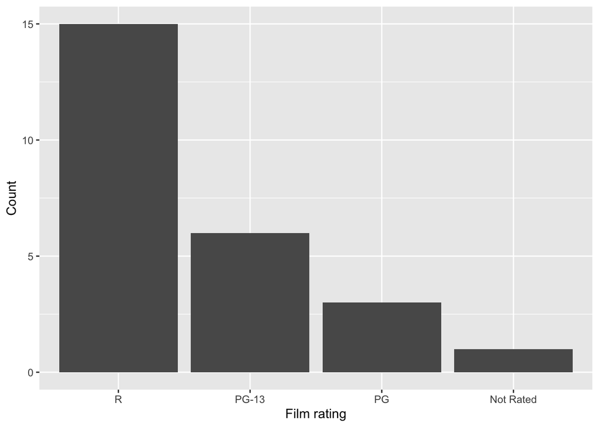

```r
# bar plot
ggplot(data = movies) +
  geom_bar(mapping = aes(x = fct_infreq(filmrating))) +
  labs(y = "count") +
  labs(x = "Film rating", y = "Count")
```

- Is there a relationship between user rating and metascore (critics rating)? How to inform the number of votes? Stratify by film rating?

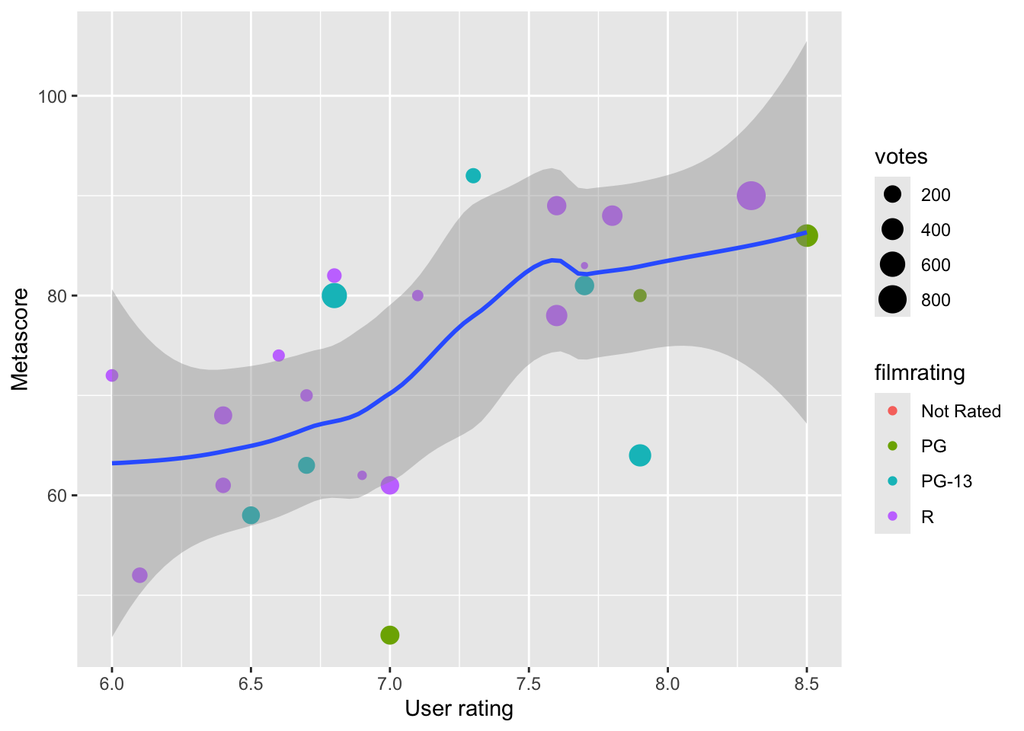

```r
ggplot(data = movies, mapping = aes(x = userrating, y = metascore)) +
  geom_point(mapping = aes(size = votes, color = filmrating)) +
  geom_smooth() +
  labs(y = "Metascore", x = "User rating")
```

## 4 Example: Scraping finance data

- `quantmod` package contains many utility functions for retrieving and plotting finance data. E.g.,

```r
library(quantmod)
stock <- getSymbols(
  "TSLA",
  src = "yahoo",
  auto.assign = FALSE,
  from = "2020-01-01"
  )
head(stock)
```

```
           TSLA.Open TSLA.High TSLA.Low TSLA.Close TSLA.Volume TSLA.Adjusted
2020-01-02  28.30000  28.71333 28.11400   28.68400   142981500      28.68400
2020-01-03  29.36667  30.26667 29.12800   29.53400   266677500      29.53400
2020-01-06  29.36467  30.10400 29.33333   30.10267   151995000      30.10267
2020-01-07  30.76000  31.44200 30.22400   31.27067   268231500      31.27067
2020-01-08  31.58000  33.23267 31.21533   32.80933   467164500      32.80933
2020-01-09  33.14000  33.25333 31.52467   32.08933   426606000      32.08933
```

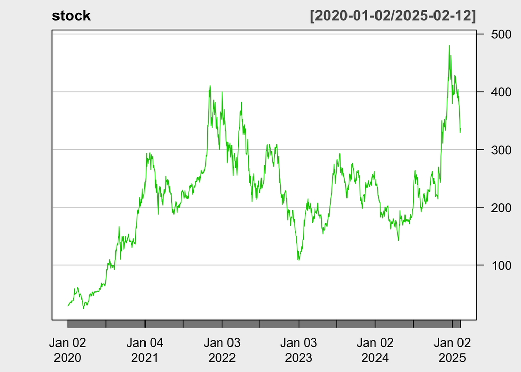

```r
chartSeries(stock, theme = chartTheme("white"),
            type = "line", log.scale = FALSE, TA = NULL)
```

## 5 Example: Pull tweets into R (not working anymore!)

- Read blog: https://towardsdatascience.com/pulling-tweets-into-r-e17d4981cfe2
- [`twitteR` package](https://www.rdocumentation.org/packages/twitteR) is useful for pulling tweets text data into R.

```r
library(twitteR) #load package
```

- Step 1: apply for a [Twitter developer account](https://developer.twitter.com). It takes some time to get approved.
- Step 2: Generate and copy the Twitter App Keys.

```
consumer_key <- 'XXXXXXXXXX'
consumer_secret <- 'XXXXXXXXXX'
access_token <- 'XXXXXXXXXX'
access_secret <- 'XXXXXXXXXX'
```

- Step 3. Set up authentication

```r
setup_twitter_oauth(consumer_key, consumer_secret, access_token, access_secret)
```

- Step 4: Pull tweets

```r
virus <- searchTwitter('#China + #Coronavirus',
                       n = 1000,
                       since = '2020-01-01',
                       retryOnRateLimit = 1e3)
virus_df <- as_tibble(twListToDF(virus))
virus_df %>% print(width = Inf)
```